# Week 2 Conjugacy (Multivariate)

Hun Kang, ESC, Yonsi University

2020 7 18

# Multivariate Normal Model

Consider a bivariate normal random variable $[y_1, y_2]^T$. The density is written as ($p=2$)

$$p(\mathbf{y}|\theta, \Sigma) = (\dfrac{1}{2\pi})^{-p/2}|\Sigma|^{-1/2}
\exp\{-\dfrac{1}{2}(\mathbf{y}-\theta)^T\Sigma^{-1}(\mathbf{y}-\theta)\}$$

where the parameter is

$$\theta =
\begin{pmatrix}
E[y_1]\\E[y_2]
\end{pmatrix},\;
\Sigma =
\begin{pmatrix}
E[y_1^2]-E[y_1]^2 & E[y_1y_2]-E[y_1]E[y_2]\\
E[y_2y_1]-E[y_2]E[y_1] & E[y_2^2]-E[y_2]^2
\end{pmatrix}
=
\begin{pmatrix}
\sigma_1^2 & \sigma_{12}\\
\sigma_{21} & \sigma_2^1
\end{pmatrix}$$

Few things worth mentioning for multivariate normal model

1. the term in the exponent $(\mathbf{y}-\theta)^T\Sigma^{-1}(\mathbf{y}-\theta)$ is somewhat a measure of distance between mean and the data. Refer to https://en.wikipedia.org/wiki/Mahalanobis_distance
2. Geometrically, MVN density is spread along the eigenvectors of $\Sigma$, a symmetric postive definite matrix, with width determined by the corresponding eigenvalues. Refer to https://youtu.be/qvNhgkbzKmY?t=358

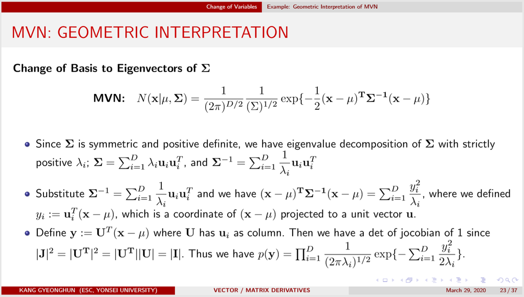

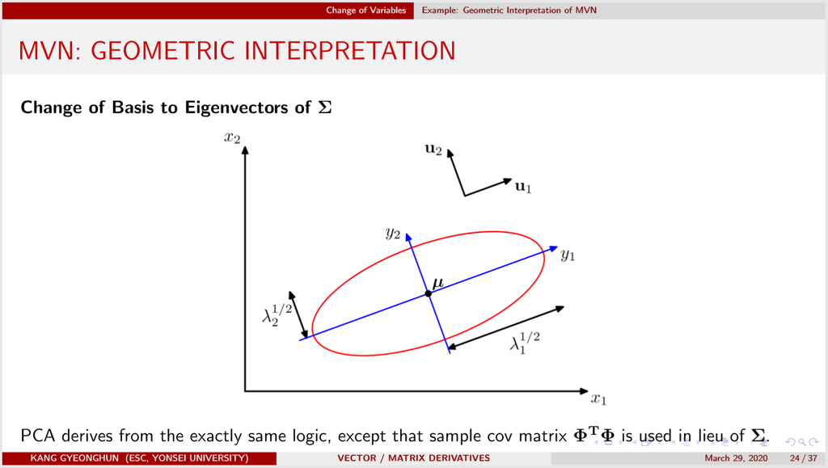

3. A bit of algebra shows that the MVN density can be written as

$$\begin{align}
p(\mathbf{y}|\theta, \Sigma) &= (\dfrac{1}{2\pi})^{-p/2}|\Sigma|^{-1/2}
\exp\{-\dfrac{1}{2}(\mathbf{y}-\theta)^T\Sigma^{-1}(\mathbf{y}-\theta)\}\\
&\propto \exp\{-\dfrac{1}{2}\mathbf{y}^T \Sigma^{-1}\mathbf{y} + \mathbf{y}^T\Sigma^{-1}\theta
-\dfrac{1}{2}\theta^T \Sigma^{-1}\theta \}\\
&\propto\exp\{-\dfrac{1}{2}\mathbf{y}^T \mathbf{A}\mathbf{y}
+\mathbf{y}^T\mathbf{b}\}\\
\text{where}\quad &
\theta = \mathbf{A^{-1}b},\quad
\Sigma = \mathbf{A^{-1}}
\end{align}$$

This is useful in doing a multivariate version of “matching the exponents”.

## Semiconjugate prior for the mean

For $\mathbf{D} = \{\mathbf{y_1}, \mathbf{y_2}, ..., \mathbf{y_n}\}$ with $p$ variables, the joint likelihood density is

$$p(\mathbf{D}|\theta, \Sigma) = (\dfrac{1}{2\pi})^{-np/2}|\Sigma|^{-n/2}
\exp\{-\dfrac{1}{2}\sum_{i=1}^n(\mathbf{y_i}-\theta)^T\Sigma^{-1}(\mathbf{y_i}-\theta)\}$$

It seems natural to consider MVN as a prior for $\theta$ of MVN likelihood.

$$\theta \sim MVN(\mu_0, \Lambda_0)$$

Then by (6), we see that

$$\begin{align}
p(\theta) &\propto \exp\{ -\dfrac{1}{2}\theta^T\mathbf{A_0}\theta + \theta^T\mathbf{b_0}\}\\
\text{where}\quad & \mathbf{A_0} = \Lambda_0^{-1},\quad \mathbf{b_0}=\Lambda_0^{-1}\mu_0\\
p(\mathbf{D}|\theta, \Sigma) &\propto \exp\{ -\dfrac{1}{2}\theta^T\mathbf{A_1}\theta + \theta^T\mathbf{b_1}\}\\
\text{where}\quad & \mathbf{A_1} = n\Sigma^{-1},\quad \mathbf{b_1}=n\Sigma^{-1}\mathbf{\bar{y}}\\
\therefore p(\theta|\mathbf{D},\Sigma) &\propto
\exp\{ -\dfrac{1}{2}\theta^T(\mathbf{A_0}+\mathbf{A_1})\theta + \theta^T(\mathbf{b_0}+\mathbf{b_1})\}\\
\end{align}$$
Hence the posterior for $\theta$ given $\mathbf{D}, \Sigma$ is

$$\begin{align}
\theta|\mathbf{D},\Sigma &\sim MVN(\mu_n, \Lambda_n)\\
\mu_n &= (\Lambda_0^{-1}+n\Sigma^{-1})^{-1}(\Lambda_0^{-1}\mu_0+n\Sigma^{-1}\mathbf{\bar{y}})\\
\Lambda_n &= (\Lambda_0^{-1}+n\Sigma^{-1})^{-1}
\end{align}$$

which is reminiscent of the univariate normal case.

## The inverse Wishart distribution for $\Sigma$ prior

When $y_i \sim N(\theta, \sigma^2)$, the sample variance follows chi-square (gamma) distribution. More generally, since $\frac{(n-1)s^2}{\sigma^2}\sim \Gamma(\frac{n-1}{2}, 2)$ we can write

$${(n-1)s^2} \sim \Gamma(\dfrac{n-1}{2}, \dfrac{1}{2\sigma^2})$$

In univariate normal, the formula $(n-1)s^2=\sum_{i=1}^n (y_i - \bar{y})^2$ is called “the sum of squares”. We can come up with a similar formula for multivariate case as follows.

$$\sum_{i=1}^n \mathbf{y_i}\mathbf{y_i^T} = \mathbf{Y^TY} \quad (\mathbf{Y}\in\mathbb{R}^{n\times p})$$

If $\mathbf{y_i} \sim MVN(\mathbf{0}, \Phi_0)$, then $\mathbf{Y^TY}$ follows a Wishart distribution with parameters $(n, \Phi_0)$, which is analogous to the univariate case.

$$\mathbf{y_i} \sim MVN(\mathbf{0}, \Phi_0) \implies \sum_{i=1}^n \mathbf{y_i}\mathbf{y_i^T} = \mathbf{Y^TY} \sim W(n, \Phi_0)$$
$\mathbf{Y^TY}$ is symmetric obviously, and also postive definite (as long as $n>p$) with probability 1. Using this result, we can construct an inverse Wishart prior for $\Sigma$ that is semi-conjugate.

**Inverse Wishart Distribution** 1. sample $\mathbf{y_i}\sim MVN(\mathbf{0}, \mathbf{S_0^{-1}})$ 2. Calculate $\sum_{i=1}^{v_0} \mathbf{y_i}\mathbf{y_i^T} = \mathbf{Y^TY}$ 3. set $\Sigma = \mathbf{Y^TY}^{-1}$. 4. $\Sigma \sim invW(v_0, \mathbf{S_0^{-1}})$, with $E[\Sigma]=\dfrac{\mathbf{S_0}}{v_0-p-1}$

It can be shown that the posterior is $\Sigma|\mathbf{D}, \theta \sim invW(v_0+n, (\mathbf{S_0}+\mathbf{S_\theta})^{-1})$ where $S_\theta = \sum_{i=1}^n(\mathbf{y_i}-\theta)(\mathbf{y_i}-\theta)^T$. The mean of the posterior is wegithed average of prior mean and sample covariance matrix, which is also comparable to single variable case.

$$E[\Sigma|\mathbf{D}, \theta] = \dfrac{v_0-p-1}{v_0-p-1+n}\dfrac{\mathbf{S_0}}{v_0-p-1}
+\dfrac{n}{v_0-p-1+n}\dfrac{\mathbf{S_\theta}}{n}$$

In summary, for MVN model, we have full conditional posteriors as follows, and we can use Gibbs Sampler to approximate the posterior.

$$\begin{align}
\theta|\Sigma, \mathbf{D} &\sim MVN(\mu_n, \Lambda_n)\\
\mu_n &= (\Lambda_0^{-1}+n\Sigma^{-1})^{-1}(\Lambda_0^{-1}\mu_0+n\Sigma^{-1}\mathbf{\bar{y}})\\
\Lambda_n &= (\Lambda_0^{-1}+n\Sigma^{-1})^{-1}\\
\\
\Sigma|\theta, \mathbf{D} &\sim invW(v_n, \mathbf{S_n^{-1}})\\
v_n &= v_0 + n\\
\mathbf{S_n^{-1}} &= (\mathbf{S_0+\sum_{i=1}^n (y_i-\theta)(y_i-\theta)^T})^{-1}
\end{align}$$

# Bayesian Linear Regression (fixed variance)

In linear regression with gaussian normal assumption we can write the likelihood of $\mathbf{y}$ as MVN with a mean which is a linear combination of coloumns of $\mathbf{X}$.

$$\mathbf{y}|\mathbf{X}, \beta, \sigma^2 \sim MVN(\mathbf{X\beta}, \sigma^2\mathbf{I})\\
p(\mathbf{y}|\mathbf{X}, \beta, \sigma^2) \propto \exp\{-\dfrac{1}{2}\mathbf{(y-X\beta)^T(y-X\beta)}\}$$

With MVN prior on $\beta \sim MVN(\mathbf{\beta_0}, \Sigma_0)$, we see that

$$\begin{align}
p(\beta|\mathbf{y}, \mathbf{X}, \sigma^2) &\propto
p(\mathbf{y}|\mathbf{X}, \beta, \sigma^2)p(\beta)\\
&\propto \exp\{-\dfrac{1}{2}\mathbf{(y-X\beta)^T(y-X\beta)}\}
\exp\{ -\dfrac{1}{2} \mathbf{(\beta-\beta_0)^T\Sigma_0^{-1}(\beta-\beta_0)} \}\\
&=\exp\{ -\dfrac{1}{2}\beta^T(\Sigma_0^{-1}+\mathbf{X^TX}/\sigma^2)\beta
+ \beta^T(\Sigma_0^{-1}\beta_0 + \mathbf{X^Ty}/\sigma^2)\}
\end{align}$$

Again by (6), we see that the posterior for $\beta$ is also normal with

$$\begin{align}
V[\beta|\mathbf{y}, \mathbf{X}, \sigma^2] &= (\Sigma_0^{-1}+\mathbf{X^TX}/\sigma^2)^{-1}\\
E[\beta|\mathbf{y}, \mathbf{X}, \sigma^2] &= (\Sigma_0^{-1}+\mathbf{X^TX}/\sigma^2)^{-1}
(\Sigma_0^{-1}\beta_0 + \mathbf{X^Ty}/\sigma^2)
\end{align}$$

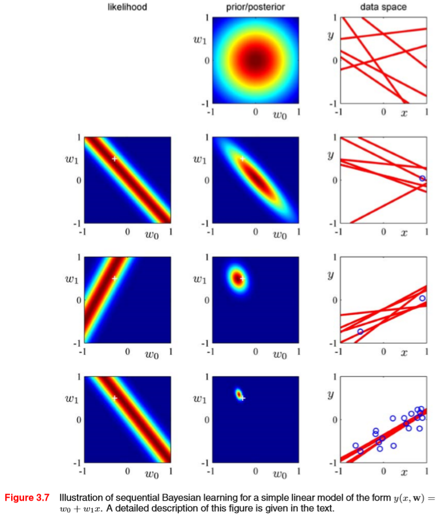

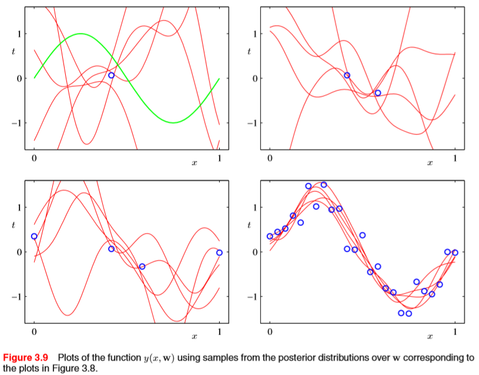

# Multinomial Model for categorical data

$$\begin{align}
\text{Likelihood}&\quad p(\mathbf{y}|\theta) \propto \prod_{j=1}^k \theta_j^{y_j}
\quad (\mathbf{y}=[y_1, y_2, ..., y_k]^T)\\
\text{Prior}&\quad p(\theta) \propto \prod_{j=1}^k \theta_j^{\alpha_j-1} \quad (\text{parameters } \alpha_1, \alpha_2, ..., \alpha_k)\\
\text{Posterior}&\quad p(\theta|\mathbf{y}) \propto \prod_{j=1}^k \theta_j^{\alpha_j+y_j-1}
\end{align}$$

## Example: pre-election polling

```r
library(DirichletReg)
```

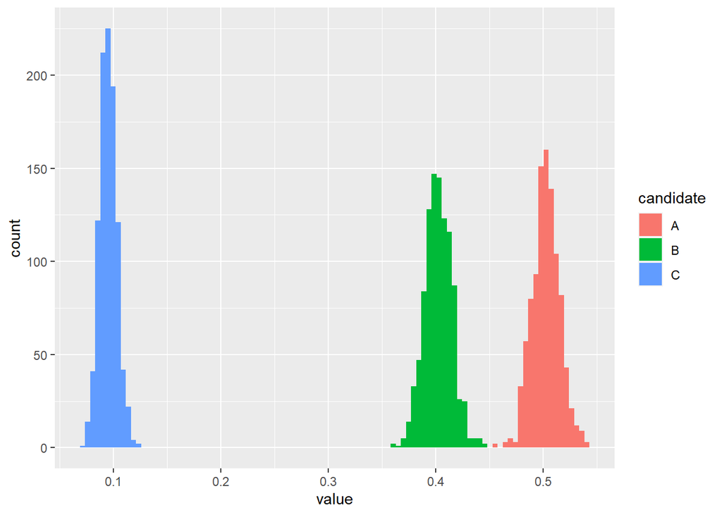

```r
# prior
a1 = a2 = a3 = 1 # weak prior

# data
y = c(727, 583, 137)

# posterior
a1 = a1 + y[1]
a2 = a2 + y[2]
a3 = a3 + y[3]

# generate samples
df = rdirichlet(1000, c(a1, a2, a3))
df = data.frame(df)
colnames(df) = c('A','B','C')

df_long = melt(df, variable_name = 'candidate')
df_diff = data.frame(diff=df$A-df$B)

ggplot(df_long, aes(x=value, fill=candidate))+ geom_histogram(bins=100)
```

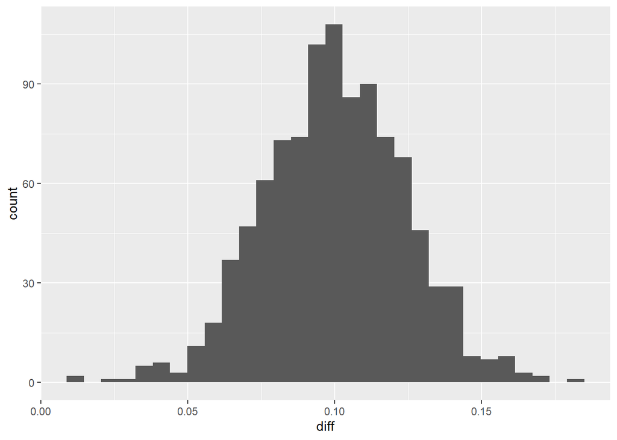

```r
ggplot(df_diff, aes(x=diff)) + geom_histogram(bins=30)
```

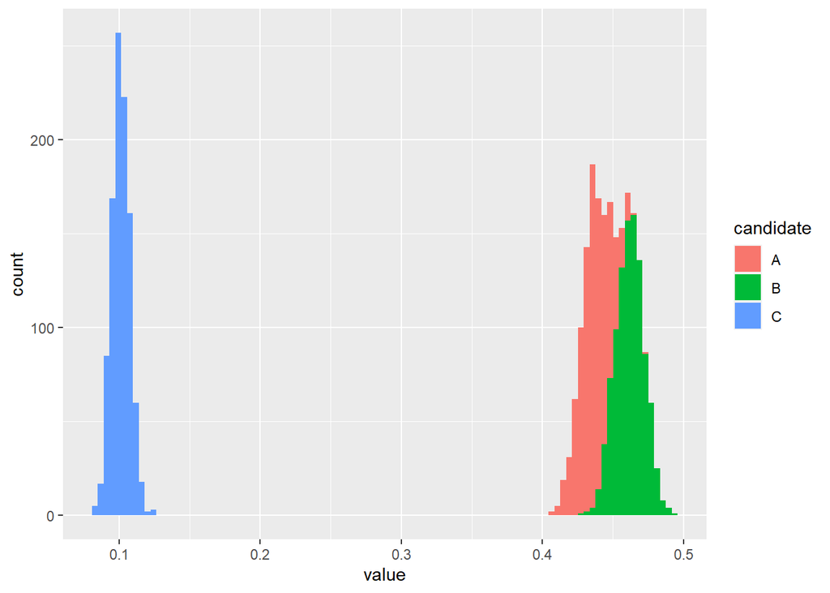

```r
# new data
y = c(300, 500, 100)
a1 = a1 + y[1]
a2 = a2 + y[2]
a3 = a3 + y[3]

# generate samples
df = rdirichlet(1000, c(a1, a2, a3))
df = data.frame(df)
colnames(df) = c('A','B','C')

df_long = melt(df, variable_name = 'candidate')
df_diff = data.frame(diff=df$A-df$B)

ggplot(df_long, aes(x=value, fill=candidate))+geom_histogram(bins=100)
```

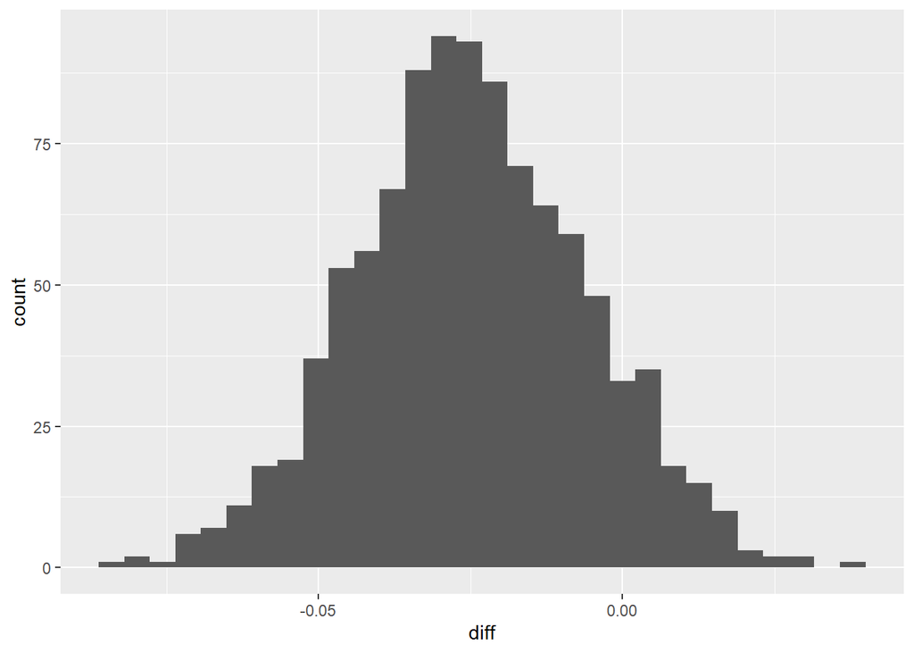

```r
ggplot(df_diff, aes(x=diff)) + geom_histogram(bins=30)
```

# References

1. First Course into Bayesian Statistical Analysis (Hoff, 2009)
2. https://github.com/jayelm/hoff-bayesian-statistics
3. Pattern Recognition and Machine Learning (Bishop, 2006) (figures)